# Project Phase 3: Team 4

### Team Members: Aayush Shah, Aniruddh Nathani, Ankita Naikdalal, Vaidehi Patil

### Task Assigment:

1) Aayush: Twitter Data Extraction, EDA, Sentiment Analysis, Final Analysis

2) Aniruddh: Reddit Data Extraction, EDA, Sentiment Analysis, Final Analysis

3) Ankita: Youtube Data Extraction, EDA, Hate Speech Model Creation and Prediction, Final Analysis

4) Vaidehi: Hate Speech Labeled Data Analysis, EDA, Hate Speech Model Creation and Prediction, Final Analysis

### Research Question: Analyzing Proliferation of Hate Speech since the Coronavirus Lockdown

The spread of COVID-19 has created waves of fear, uncertainty, and anxiety across the globe. With social media being the prime platform for people to spread hateful speech amongst the community, the issue of online hate speech seems to be exacerbated by the ongoing COVID-19 pandemic. To analyze whether the pandemic has led to a speard of hate speech on social media platforms, we have gathered data from popular social media platforms such as Twitter, Youtube and Reddit before and after the lockdown to analyze whether there has been an increase in the spread of hate speech on these social media platforms.

### Step 1: Data Collection

We have used Twitter, YouTube and Reddit API's for collecting data post the COVID-19 pandemic. In order to narrow the scope of the data collected and have a common theme for our analysis, we have extracted data from the above platforms only pertaining to the "jobs", "education", and "job search" themes.

### a) YouTube comments extraction

The below code details the process used to scrape the data from the YouTube comments section.

Reference: https://python.gotrained.com/youtube-api-extracting-comments/

Kaggle dataset for pre-lockdown data: https://www.kaggle.com/gaurav2022/youtube-scrapped-data

```python
# Importing libraries

import csv
import os
import pandas as pd
import numpy as np
import re, string
import json
import tweepy
import seaborn as sns
from collections import defaultdict
from psaw import PushshiftAPI
import praw
import datetime as dt
from datetime import datetime,timedelta, date
from searchtweets import collect_results
from searchtweets import ResultStream, load_credentials, gen_request_parameters
import requests
import json
import nltk
import lightgbm as lgb
import unicodedata
from sklearn.feature_extraction.text import CountVectorizer
from sklearn.model_selection import train_test_split
from sklearn.feature_extraction.text import TfidfVectorizer
from sklearn.naive_bayes import MultinomialNB
from sklearn.metrics import accuracy_score, f1_score, precision_score, recall_score, classification_report,confusion_matrix
from sklearn.linear_model import LogisticRegression
import random
import matplotlib.pyplot as plt
from wordcloud import WordCloud
```

```python
import google.oauth2.credentials
from googleapiclient.discovery import build
from googleapiclient.errors import HttpError
from google_auth_oauthlib.flow import InstalledAppFlow
```

#### Loading the client_secret keys file

```python
# The CLIENT_SECRETS_FILE variable specifies the name of a file that contains
#the OAuth 2.0 information for this project, including its client_id and
# client_secret.

CLIENT_SECRETS_FILE = "client_secret.json"

# This OAuth 2.0 access scope allows for full read/write access to the
# authenticated user's account and requires requests to use an SSL connection.

SCOPES = ['https://www.googleapis.com/auth/youtube.force-ssl']
API_SERVICE_NAME = 'youtube'
API_VERSION = 'v3'
```

#### Defining functions for data extraction

```python
# The following function grabs the constants defined before, builds and returns the service that will interact with the API.

def get_authenticated_service():
    credentials = None
    if os.path.exists('token.pickle'):
        with open('token.pickle', 'rb') as token:
            credentials = pickle.load(token)

    #  Check if the credentials are invalid or do not exist
    if not credentials or not credentials.valid:

        # Check if the credentials have expired
        if credentials and credentials.expired and credentials.refresh_token:
            credentials.refresh(Request())
        else:
            flow = InstalledAppFlow.from_client_secrets_file(
                CLIENT_SECRETS_FILE, SCOPES)
            credentials = flow.run_console()

        # Save the credentials for the next run
        with open('token.pickle', 'wb') as token:
            pickle.dump(credentials, token)

    return build(API_SERVICE_NAME, API_VERSION, credentials = credentials)
```

```python
#This function gets the video results from the specified number of pages

def get_videos(service, **kwargs):
    final_results = []
    results = service.search().list(**kwargs).execute()

    i = 0
    max_pages = 3
    while results and i < max_pages:
        final_results.extend(results['items'])

        # Check if another page exists
        if 'nextPageToken' in results:
            kwargs['pageToken'] = results['nextPageToken']
            results = service.search().list(**kwargs).execute()
            i += 1
        else:
            break

    return final_results
```

```python
# This function seearches the videos based on the keywords provided

def search_videos_by_keyword(service, **kwargs):
    results = get_videos(service, **kwargs)
    final_result = []
    for item in results:
        title = item['snippet']['title']
        video_id = item['id']['videoId']
        comments,date = get_video_comments(service, part='snippet', videoId=video_id, textFormat='plainText')
        # make a tuple consisting of the video id, title, comment and add the result to
        # the final list
        final_result.extend([(video_id, title, comment,date) for comment in comments])

    write_to_csv(final_result)
```

```python
# This function extracts the video comments and other related fields from every fetched video

def get_video_comments(service, **kwargs):
    comments = []
    date=[]
    results = service.commentThreads().list(**kwargs).execute()

    while results:
        for item in results['items']:
            comment = item['snippet']['topLevelComment']['snippet']['textDisplay']
            updated_at = item['snippet']['topLevelComment']['snippet']['updatedAt']
            comments.append(comment)
            date.append(updated_at)

        # Check if another page exists
        if 'nextPageToken' in results:
            kwargs['pageToken'] = results['nextPageToken']
            results = service.commentThreads().list(**kwargs).execute()
        else:
            break

    return comments,date
```

```python
# This function writes the data to a csv file

def write_to_csv(comments):
    with open('yt_data_post.csv', 'w',encoding="utf-8") as comments_file:
        comments_writer = csv.writer(comments_file, delimiter=',', quotechar='"', quoting=csv.QUOTE_MINIMAL)
        comments_writer.writerow(['Video ID', 'Title', 'Comment',"Date"])
        for row in comments:
            # convert the tuple to a list and write to the output file
            comments_writer.writerow(list(row))
```

#### Extracting YouTube comments data

```python
# Main function to call for data extraction

if __name__ == '__main__':
    os.environ['OAUTHLIB_INSECURE_TRANSPORT'] = '1'
    service = get_authenticated_service()
    keyword = "jobs"
    search_videos_by_keyword(service, q=keyword, part='id,snippet', eventType='completed', type='video')
```

#### Loading the YouTube comments post the COVID-19 pandemic

```python
yt_data_post=pd.read_csv("yt_data_post.csv")
yt_data_post.head()
```

|  | Video ID | Title | Comment | Date |
| --- | --- | --- | --- | --- |
| 0 | E-_q9MSdpQE | HOW TO GET FEDERAL GOVERNMENT JOBS: Direct hir... | Hello Have a question, \r\nCurrently looking f... | ['2021-02-01T19:49:08Z', '2021-01-31T22:38:29Z... |
| 1 | E-_q9MSdpQE | HOW TO GET FEDERAL GOVERNMENT JOBS: Direct hir... | Hello, I am recently offered a position for an... | ['2021-02-01T19:49:08Z', '2021-01-31T22:38:29Z... |
| 2 | E-_q9MSdpQE | HOW TO GET FEDERAL GOVERNMENT JOBS: Direct hir... | I wanna be head over federal national parks, a... | ['2021-02-01T19:49:08Z', '2021-01-31T22:38:29Z... |
| 3 | E-_q9MSdpQE | HOW TO GET FEDERAL GOVERNMENT JOBS: Direct hir... | But I hear you have to be a citizen to work fo... | ['2021-02-01T19:49:08Z', '2021-01-31T22:38:29Z... |
| 4 | E-_q9MSdpQE | HOW TO GET FEDERAL GOVERNMENT JOBS: Direct hir... | I have worked in corporate America for most of... | ['2021-02-01T19:49:08Z', '2021-01-31T22:38:29Z... |

### Data cleaning and EDA for the YouTube datasets

#### Post pandemic data

The extracted dataset has 3350 rows and 4 columns. The data has no null values for any of the columns. However, the date column is not extracted in the proper format and needs more cleaning.

```python
yt_data_post.shape
```

```
(3350, 4)
```

```python
yt_data_post.isna().sum()
```

```
Video ID    0
Title       0
Comment     0
Date        0
dtype: int64
```

```python
yt_data_post.describe()
```

|  | Video ID | Title | Comment | Date |
| --- | --- | --- | --- | --- |
| count | 3350 | 3350 | 3350 | 3350 |
| unique | 14 | 14 | 3090 | 14 |
| top | uF52X3yL0gY | Servant Hiring 2021 House Keeping Job | Hi | ['2021-01-29T17:09:40Z', '2021-02-21T21:57:47Z... |
| freq | 1946 | 1946 | 35 | 1946 |

#### Cleaning the date column

```python
yt_data_post['Date']=yt_data_post['Date'].str.split()
yt_data_post['Date']=yt_data_post['Date'].str[0]
yt_data_post['Date']=yt_data_post['Date'].str.replace('"', '')
yt_data_post['Date']=yt_data_post['Date'].str.replace("'", '')
yt_data_post['Date']=yt_data_post['Date'].str.replace("[", '')
yt_data_post['Date']= pd.to_datetime(yt_data_post['Date'])
yt_data_post['Date']=yt_data_post['Date'].dt.date
```

```python
yt_data_post=yt_data_post[yt_data_post['Date'] >  pd.to_datetime('2020-09-01')]
```

#### Subsetting the data

```python
yt_data_post=yt_data_post[["Comment","Date"]]
```

```python
yt_data_post.head()
```

|  | Comment | Date |
| --- | --- | --- |
| 0 | Hello Have a question, \r\nCurrently looking f... | 2021-02-01 |
| 1 | Hello, I am recently offered a position for an... | 2021-02-01 |
| 2 | I wanna be head over federal national parks, a... | 2021-02-01 |
| 3 | But I hear you have to be a citizen to work fo... | 2021-02-01 |
| 4 | I have worked in corporate America for most of... | 2021-02-01 |

#### Pre-pandemic data

The extracted dataset has 515 rows and 8 columns. A few columns in the dataset have null values and since the number of rows with null values is small we have dropped those observations from our dataset. We have changed the format of the date column to match the other dataset. Additionally, we have kept only the "Comments" and "Date" columns as only these 2 column will be used for further analysis.

```python
yt_data_pre=pd.read_csv("yt_data_pre.csv")
yt_data_pre.head()
```

|  | Unnamed: 0 | Video Link | Video Title | Views | Uploaded Date | Likes on Video | Dislikes on Video | Comments |
| --- | --- | --- | --- | --- | --- | --- | --- | --- |
| 0 | 0 | https://www.youtube.com/watch?v=bWWTk-pZX5g | 8 fiction books you need to read📚(& that will ... | 382,446 views | 23 Mar 2020 | 18K | 341 | Yoo Se Na - "You know what sexy?....\nBooks."\... |
| 1 | 1 | https://www.youtube.com/watch?v=gyK9USvrvDQ | Top 10 BEST SELLING Books In History | 575,824 views | 25 Aug 2018 | 12K | 992 | - Hello Aluxers, what's your favorite book se... |
| 2 | 2 | https://www.youtube.com/watch?v=GihybX7JyG4 | (Full Audiobook) This Book Will Change Everyth... | 4,692,014 views | 26 Oct 2017 | 61K | 4.3K | Brian Perkins - I love audiobooks. I use youtu... |
| 3 | 3 | https://www.youtube.com/watch?v=4f2OCYaqLdE | I Read Every Book Joe from You Recommended | 1,977,658 views | 25 Jan 2020 | 99K | 734 | Ishaan Vohra - Watching a smart guy do smart t... |
| 4 | 4 | https://www.youtube.com/watch?v=imA5NPX4ucU | SUPER BIG BOOKHAUL aka *leo has a book buying ... | 2,450 views | 23 Jul 2020 | 233 | 0 | Sabine's Book Nook - Us both having a book buy... |

```python
yt_data_pre.isna().sum()
```

```
Unnamed: 0            0
Video Link            0
Video Title           3
Views                 2
Uploaded Date         2
Likes on Video        1
Dislikes on Video     1
Comments             27
dtype: int64
```

```python
yt_data_pre.shape
```

```
(515, 8)
```

#### Dropping null values

```python
yt_data_pre=yt_data_pre.dropna()
```

```python
yt_data_pre['Uploaded Date']=pd.to_datetime(yt_data_pre['Uploaded Date'], errors='coerce')
```

#### Formatting the "Date" column

```python
yt_data_pre=yt_data_pre.dropna()
```

```python
yt_data_pre=yt_data_pre[yt_data_pre['Uploaded Date'] <  pd.to_datetime('2020-03-01')]
```

#### Subsetting the data

```python
yt_data_pre=yt_data_pre[["Comments","Uploaded Date"]]
yt_data_pre.columns=["Comment", "Date"]
```

```python
yt_data_pre.head()
```

|  | Comment | Date |
| --- | --- | --- |
| 1 | - Hello Aluxers, what's your favorite book se... | 2018-08-25 |
| 2 | Brian Perkins - I love audiobooks. I use youtu... | 2017-10-26 |
| 3 | Ishaan Vohra - Watching a smart guy do smart t... | 2020-01-25 |
| 6 | - Hello Aluxers, Which of these 15 Books have... | 2019-05-01 |
| 7 | - You've been asking for it so we did it! Whi... | 2017-11-26 |

#### Creating a combined YouTube dataset

```python
yt_data=yt_data_pre.append(yt_data_post, ignore_index=True)
```

```python
yt_data["Date"]=pd.to_datetime(yt_data['Date'])
yt_data["Date"]=yt_data["Date"].dt.date
```

### Performing basic cleaning on the YouTube data

```python
# Basic function to clean the text data

def clean_data(text):
    text = text.lower() # make all text to lowercase
    text = re.sub('\[.*?\]', '', text) # removing data in brackets
    text = re.sub('[%s]' % re.escape(string.punctuation), '', text) #removing punctuations
    text = re.sub('—', '', text) #removing double hyphens
    text = re.sub(r'\w*\d+\w*', '', text) #removing words containing numbers
    text = re.sub("@\S+", " ", text) #removing mentions
    text = re.sub("https*\S+", " ", text) #removing URLs
    text = re.sub("#\S+", " ", text) #removing hashtags
    text = re.sub(r'rt ', '', text) #removing retweet abbr
    text = text.replace('\n','') # remove '\n' from tweets/reddits

    return text
```

```python
yt_data["Clean_Comment"]=yt_data["Comment"].apply(clean_data)
yt_data["Source"]="youtube"
```

```python
yt_data
```

|  | Comment | Date | Clean_Comment | Source |
| --- | --- | --- | --- | --- |
| 0 | - Hello Aluxers, what's your favorite book se... | 2018-08-25 | hello aluxers whats your favorite book serie... | youtube |
| 1 | Brian Perkins - I love audiobooks. I use youtu... | 2017-10-26 | brian perkins i love audiobooks i use youtube... | youtube |
| 2 | Ishaan Vohra - Watching a smart guy do smart t... | 2020-01-25 | ishaan vohra watching a smaguy do smathings a... | youtube |
| 3 | - Hello Aluxers, Which of these 15 Books have... | 2019-05-01 | hello aluxers which of these books have you... | youtube |
| 4 | - You've been asking for it so we did it! Whi... | 2017-11-26 | youve been asking for it so we did it which ... | youtube |
| ... | ... | ... | ... | ... |
| 3575 | Mobil No send me please | 2020-09-27 | mobil no send me please | youtube |
| 3576 | Hi sir | 2020-09-27 | hi sir | youtube |
| 3577 | Bro, hardware networking course chesanu jobs E... | 2020-09-27 | bro hardware networking course chesanu jobs el... | youtube |
| 3578 | Bro school students jobs Plzzz reply bro | 2020-09-27 | bro school students jobs plzzz reply bro | youtube |
| 3579 | Hiii brooo | 2020-09-27 | hiii brooo | youtube |

3580 rows × 4 columns

#### Saving the YouTube dataset as a csv

```python
yt_data.to_csv("youtube_data.csv")
```

### b) Twitter Data Collection

We have used the Twitter API to extract data related to the "jobs" or "unemployment" themes from Twitter during the post pandemic period. We have used a premium Twitter API to access archived data before the pandemic started.

```python
#Loading the API keys

def loadKeys(key_file):
    with open(key_file) as f:
        key_dict = json.load(f)
    return key_dict['api_key'], key_dict['api_secret'], key_dict['token'], key_dict['token_secret']
```

```python
#Setting access tokens

KEY_FILE = 'twitterkeys.json'
api_key, api_secret, token, token_secret = loadKeys(KEY_FILE)
auth = tweepy.OAuthHandler(api_key, api_secret)
auth.set_access_token(token, token_secret)
api = tweepy.API(auth)
```

```python
#Extracting tweets for selected keywords

search_term = "#jobs OR #unemployement" + "-filter:retweets"
no_of_pages = 20
tweets_save = []
for page in tweepy.Cursor(api.search, q = search_term, lang="en",).pages(no_of_pages):
    for status in page:
        tweets_save.append([status.created_at, status.text])
```

#### Saving the extracted tweets in a dataframe

```python
new_tweets = pd.DataFrame(tweets_save)
```

```python
# Subsetting the dataframe

new_tweets = new_tweets.rename(columns={0: "created_at", 1: "tweet"})
```

### Pre-pandemic Twitter dataset

Extracting data from the pre-pandemic period using Twitter Premium API used for archived data extraction.

```python
tweets_save_pre = []

def credential_args(filename="~/.credential.yaml",yaml_key="search_tweets_premium"):
    premium_search_args = load_credentials(filename,
                                       yaml_key=yaml_key,
                                       env_overwrite=False)
    return premium_search_args

def search_rules(q, filters=None, fromdate=None, todate=None, results_per_call=100,tag="covid"):
        query = q
        if filters:
            query = q + ' ' + filters
        rule = gen_request_parameters(query= query, start_time=fromdate, end_time=todate, expansions="geo.place_id,author_id",
                                        results_per_call = results_per_call,
                                        user_fields="id,location,verified",place_fields="place_type,name,country_code",
                                        tweet_fields="id,created_at,text,in_reply_to_user_id,lang,geo,author_id,possibly_sensitive,public_metrics")

        return rule

def fetch_results(query_rule,result_stream_args,max_results=100):
    tweets = collect_results(query_rule,
                            max_tweets=max_results,
                            result_stream_args=result_stream_args) # change this if you need to
    return tweets

def search_geocity(query,headers):
    endpoint='https://api.twitter.com/1.1/geo/search.json'
    params = {'query':query,'granularity':'neighborhood','trim_place':'true'}
    res = requests.get(url=endpoint, params=params, headers=headers)
    print(res.text)

if __name__=='__main__':
    START_OVER = False
    MAX_TWEETS = 100

    search_args = credential_args(filename="./credential.yaml",yaml_key="search_tweets_premium")

    covid_search_term = "#jobs OR #unemployement" #search term
    keywords = {'covid_search':covid_search_term}
    dates = ["2020-01-01","2020-01-10"] #pre-covid dates
    error_tweets= {}
    error_id = 0
    for START_DATE in dates:
        default_place={'place_id':0}
        for i in range(0,31,1):
            datetime_object = datetime.strptime(START_DATE, '%Y-%m-%d')
            query_start_date = datetime_object+ timedelta(i)
            query_end_date = datetime_object+ timedelta(i+1)
            print(f"Quering for start date {query_start_date} and end date {query_end_date}")
            for query, value in keywords.items():
               # for city, radius in cities:
                #point_radius:[longitude latitude radius]
                rule = search_rules(value,filters=f"lang:en -is:retweet -is:reply" #has:geo (place:{city} OR point_radius:[{radius[1]} {radius[0]} {radius[2]}mi])"
                                    ,fromdate=query_start_date.strftime('%Y-%m-%d')
                                    ,todate=query_end_date.strftime('%Y-%m-%d'))
                #print(f"Query Rule {rule}")
                tweets = fetch_results(rule,search_args,MAX_TWEETS)
                for tweet in tweets:
                    tweets_save_pre.append([tweet.get('created_at'), tweet.get('text')])
```

#### Saving the pre pandemic tweets dataframe

```python
old_tweets = pd.DataFrame(tweets_save_pre)
```

```python
old_tweets = old_tweets.rename(columns={0: "created_at", 1: "tweet"})
```

```python
old_tweets.to_csv("tweets_pre.csv")
```

#### Merging the pre and post pandemic Twitter datasets

```python
twitter_df = old_tweets.append(new_tweets, ignore_index=True)
```

```python
twitter_df
```

|  | created_at | tweet |
| --- | --- | --- |
| 0 | 2020-01-01T23:59:58.000Z | Chef de Partie, Alton, £22k - 24k/year + Tronc... |
| 1 | 2020-01-01T23:59:54.000Z | Deputy Manager , Sevenoaks, £20k - 24k/year +... |
| 2 | 2020-01-01T23:59:53.000Z | RT @wildcatvc: #JobOfTheWeek Reach is looking ... |
| 3 | 2020-01-01T23:59:51.000Z | Roving Sous Chef, Kent, £26k - 28k/year + Tips... |
| 4 | 2020-01-01T23:59:42.000Z | Group Manager , London, £32,658/year + benef... |
| ... | ... | ... |
| 2062 | 2021-03-09 17:25:34 | New #job: Property Accounts Assistant Location... |
| 2063 | 2021-03-09 17:25:34 | Home Depot looking to fill more than 3,000 job... |
| 2064 | 2021-03-09 17:25:33 | Technical Solutions is seeking an experienced ... |
| 2065 | 2021-03-09 17:25:26 | Senior Commercial Property Solicitor, United K... |
| 2066 | 2021-03-09 17:25:17 | FLT Driver - Birmingham - Staffline Express #j... |

2067 rows × 2 columns

### Data cleaning and EDA for the Twitter dataset

```python
twitter_df.shape
```

```
(2067, 2)
```

```python
twitter_df.isna().sum()
```

```
created_at    68
tweet         68
dtype: int64
```

```python
twitter_df=twitter_df.dropna()
```

```python
twitter_df.describe()
```

|  | created_at | tweet |
| --- | --- | --- |
| count | 1999 | 1999 |
| unique | 1763 | 1923 |
| top | 2020-01-17T23:51:49.000Z | RT @LindaSuhler: Don’t miss President Donald T... |
| freq | 7 | 6 |

```python
# Formatting the date column
twitter_df.created_at=pd.to_datetime(twitter_df.created_at)
twitter_df.created_at=twitter_df.created_at.dt.date
```

```python
twitter_df
```

|  | created_at | tweet |
| --- | --- | --- |
| 0 | 2020-01-01 | Chef de Partie, Alton, £22k - 24k/year + Tronc... |
| 1 | 2020-01-01 | Deputy Manager , Sevenoaks, £20k - 24k/year +... |
| 2 | 2020-01-01 | RT @wildcatvc: #JobOfTheWeek Reach is looking ... |
| 3 | 2020-01-01 | Roving Sous Chef, Kent, £26k - 28k/year + Tips... |
| 4 | 2020-01-01 | Group Manager , London, £32,658/year + benef... |
| ... | ... | ... |
| 2062 | 2021-03-09 | New #job: Property Accounts Assistant Location... |
| 2063 | 2021-03-09 | Home Depot looking to fill more than 3,000 job... |
| 2064 | 2021-03-09 | Technical Solutions is seeking an experienced ... |
| 2065 | 2021-03-09 | Senior Commercial Property Solicitor, United K... |
| 2066 | 2021-03-09 | FLT Driver - Birmingham - Staffline Express #j... |

1999 rows × 2 columns

#### Cleaning the dataset

```python
#Cleaning the tweets

twitter_df["clean_tweet"] = twitter_df["tweet"].apply(clean_data)
```

```python
twitter_df["Source"]="twitter"
```

```python
twitter_df
```

|  | created_at | tweet | clean_tweet | Source |
| --- | --- | --- | --- | --- |
| 0 | 2020-01-01 | Chef de Partie, Alton, £22k - 24k/year + Tronc... | chef de partie alton £ tronc tips benefit... | twitter |
| 1 | 2020-01-01 | Deputy Manager , Sevenoaks, £20k - 24k/year +... | deputy manager sevenoaks £ tips bonus l... | twitter |
| 2 | 2020-01-01 | RT @wildcatvc: #JobOfTheWeek Reach is looking ... | wildcatvc joboftheweek reach is looking for a ... | twitter |
| 3 | 2020-01-01 | Roving Sous Chef, Kent, £26k - 28k/year + Tips... | roving sous chef kent £ tips bonus mileag... | twitter |
| 4 | 2020-01-01 | Group Manager , London, £32,658/year + benef... | group manager london £ benefits job jobs h... | twitter |
| ... | ... | ... | ... | ... |
| 2062 | 2021-03-09 | New #job: Property Accounts Assistant Location... | new job property accounts assistant location h... | twitter |
| 2063 | 2021-03-09 | Home Depot looking to fill more than 3,000 job... | home depot looking to fill more than jobs her... | twitter |
| 2064 | 2021-03-09 | Technical Solutions is seeking an experienced ... | technical solutions is seeking an experienced ... | twitter |
| 2065 | 2021-03-09 | Senior Commercial Property Solicitor, United K... | senior commercial property solicitor united ki... | twitter |
| 2066 | 2021-03-09 | FLT Driver - Birmingham - Staffline Express #j... | flt driver birmingham staffline express jobs... | twitter |

1999 rows × 4 columns

#### Saving the dataset as a csv file

```python
twitter_df.to_csv("twitter_data_new.csv")
```

### c) Reddit Data Collection

We are using the Reddit API to collect subreddits from the pre and post lockdown period.

```python
api = PushshiftAPI()
```

```python
# Loading the API keys

reddit = praw.Reddit(client_id="643jAMxCcLgLzg",
                      client_secret="6RTPWPUwe1l6l1b1-sfxKBndRxK-5w",
                      password="$yuM!sM29h2S:8E",
                      username="AniruddhNathani",
                      user_agent="redditFetch")
```

```
Version 7.1.0 of praw is outdated. Version 7.2.0 was released Wednesday February 24, 2021.
```

```python
api = PushshiftAPI(reddit)
```

```python
# Setting keywords for subreddit extraction

gen = api.search_submissions(limit=100)
results = list(gen)
subredditList = ['remotework','Productivity','Jobs','GetEmployed','Unemployed','Unemployment']
```

```python
# Collecting subreddits from January 2020

subredditsJanuary = defaultdict(list)
start_epoch=int(dt.datetime(2020, 1, 1).timestamp())
end_epoch=int(dt.datetime(2020, 1, 11).timestamp())
for subreddit in subredditList:
    risingSubreddits=list(api.search_submissions(after=start_epoch,before = end_epoch,
                                subreddit=subreddit,
                                filter=['url','author', 'title', 'subreddit', 'selftext'], limit = 2000))
    for submission in risingSubreddits:
        subredditsJanuary['Title'].append(submission.title)
        subredditsJanuary['subreddit'].append(submission.subreddit_name_prefixed)
        subredditsJanuary["url"].append(submission.url)
        subredditsJanuary["Text"].append(submission.selftext)
        subredditsJanuary["Date"].append(dt.datetime.fromtimestamp(submission.created_utc).strftime('%Y-%m-%d'))
subredditsJanuaryDataFrame = pd.DataFrame(subredditsJanuary)
```

```python
# Collecting subreddits from July 2020

subredditsJune = defaultdict(list)
start_epoch=int(dt.datetime(2020, 6, 1).timestamp())
end_epoch=int(dt.datetime(2020, 6, 11).timestamp())
for subreddit in subredditList:
    risingSubreddits=list(api.search_submissions(after=start_epoch,before=end_epoch,
                                subreddit=subreddit,
                                filter=['url','author', 'title', 'subreddit', 'selftext'], limit = 2000))
    for submission in risingSubreddits:
        subredditsJune['Title'].append(submission.title)
        subredditsJune['subreddit'].append(submission.subreddit_name_prefixed)
        subredditsJune["url"].append(submission.url)
        subredditsJune["Text"].append(submission.selftext)
        subredditsJune["Date"].append(dt.datetime.fromtimestamp(submission.created_utc).strftime('%Y-%m-%d'))
subredditsJuneDataFrame = pd.DataFrame(subredditsJune)
```

### Data cleaning and EDA for the Reddit dataset

```python
#Cleaning the text data for January

subredditsJanuaryDataFrame['Text'] = subredditsJanuaryDataFrame.apply(lambda row: clean_data(row['Text']), axis=1)
subredditsJanuaryDataFrame['Text'].replace('', np.nan, inplace=True)
subredditsJanuaryDataFrame = subredditsJanuaryDataFrame.dropna().reset_index(drop=True)
subredditsJanuaryDataFrame.head()
```

[output not shown]

```python
#Cleaning the text data for June

subredditsJuneDataFrame['Text'] = subredditsJuneDataFrame.apply(lambda row: clean_data(row['Text']), axis=1)
subredditsJuneDataFrame['Text'] = subredditsJuneDataFrame.apply(lambda row: stopWordRemoval(row['Text']), axis=1)
subredditsJuneDataFrame['Text'].replace('', np.nan, inplace=True)
subredditsJuneDataFrame = subredditsJuneDataFrame.dropna().reset_index(drop=True)
subredditsJuneDataFrame.head()
```

|  | Title | subreddit | url | Text | Date |
| --- | --- | --- | --- | --- | --- |
| 0 | Automated tool can keep remote teams happy, en... | r/remotework | https://www.reddit.com/r/remotework/comments/h... | what’s missing new world next normal tools org... | 2020-06-10 |
| 1 | Just created my first issue of newsletter focu... | r/remotework | https://www.reddit.com/r/remotework/comments/h... | news viewsestonia passed bill creation digital... | 2020-06-10 |
| 2 | [for hire] hard working stay at home dad | r/remotework | https://www.reddit.com/r/remotework/comments/h... | hello job help refugees resettled individuals ... | 2020-06-10 |
| 3 | Remote Job boards for Canada | r/remotework | https://www.reddit.com/r/remotework/comments/h... | ive trying find remote work little seems like ... | 2020-06-10 |
| 4 | I want to thank this outstanding community! | r/remotework | https://www.reddit.com/r/remotework/comments/h... | got job it’s six month finally begin clear mas... | 2020-06-09 |

#### Merging the dataframes

```python
reddit_data=pd.concat([subredditsJanuaryDataFrame,subredditsJuneDataFrame], ignore_index=False)
```

#### Subsetting the dataframe

```python
reddit_data=reddit_data[["Text","Date"]]
```

#### Final dimension and null value check on the reddit data

```python
reddit_data.shape
```

```
(582, 2)
```

```python
reddit_data.isna().sum()
```

```
Text    0
Date    0
dtype: int64
```

```python
reddit_data.describe()
```

|  | Text | Date |
| --- | --- | --- |
| count | 582 | 582 |
| unique | 577 | 20 |
| top | something holding back productive hit wall kee... | 2020-06-10 |
| freq | 2 | 148 |

```python
reddit_data["Source"]="reddit"
```

```python
reddit_data.head()
```

|  | Text | Date | Source |
| --- | --- | --- | --- |
| 0 | weve small remote team two years bumps staying... | 2020-01-10 | reddit |
| 1 | built newsletter featuring one breakout remote... | 2020-01-09 | reddit |
| 2 | built partly go feel one key things building s... | 2020-01-09 | reddit |
| 3 | got job offer yesterday remote company today s... | 2020-01-08 | reddit |
| 4 | negotiating work home arrangement orthodox off... | 2020-01-08 | reddit |

#### Saving the reddit data in a csv file

```python
reddit_data.to_csv("reddit_data.csv")
```

### Combining the Twitter, Reddit and YouTube datasets

Ultimately, we have collect, processed and cleaned over 6000 rows of data from Twitter, Reddit and YouTube from the pre and post COVID-19 pandemic period to conduct our further analysis.

```python
reddit_data=pd.read_csv("reddit_data.csv")
twitter_data=pd.read_csv("twitter_data_new.csv")
yt_data=pd.read_csv("youtube_data.csv")
```

```python
# Reddit dataset
reddit_data_final=reddit_data[["Text","Date", "Source"]]
```

```python
# Youtube dataset
yt_data_final=yt_data[["Clean_Comment","Date","Source"]]
yt_data_final.columns=["Text","Date", "Source"]
```

```python
# Twitter dataset

twitter_data_final=twitter_data[["clean_tweet","created_at","Source"]]
twitter_data_final.columns=["Text","Date", "Source"]
```

```python
# Merging the 3 datasets

final_df=pd.concat([twitter_data_final, yt_data_final, reddit_data_final],axis=0, ignore_index=True)
```

```python
final_df
```

|  | Text | Date | Source |
| --- | --- | --- | --- |
| 0 | chef de partie alton £ tronc tips benefit... | 2020-01-01 | twitter |
| 1 | deputy manager sevenoaks £ tips bonus l... | 2020-01-01 | twitter |
| 2 | wildcatvc joboftheweek reach is looking for a ... | 2020-01-01 | twitter |
| 3 | roving sous chef kent £ tips bonus mileag... | 2020-01-01 | twitter |
| 4 | group manager london £ benefits job jobs h... | 2020-01-01 | twitter |
| ... | ... | ... | ... |
| 6156 | ive unemployment insurance benefits state iowa... | 6/10/2020 | reddit |
| 6157 | brother works full time wife can’t work stay k... | 6/10/2020 | reddit |
| 6158 | unable work table job babysitting back pandemi... | 6/10/2020 | reddit |
| 6159 | hello helped mother apply ui applied shortly a... | 6/10/2020 | reddit |
| 6160 | pua issuehas anyone issue “unemployment result... | 6/10/2020 | reddit |

6161 rows × 3 columns

```python
#Saving the data in  csv file

final_df.to_csv("combined_final_data.csv", index=False)
```

### d) Labelled Hate Speech Dataset for training the hate speech detection model

We are using the labeled hatespeech dataset used in the research paper - *Automated Hate Speech Detection and the Problem of Offensive Language* to train our hate speech classifier model.

Paper Reference: https://arxiv.org/pdf/1703.04009.pdf  
Dataset Reference: https://github.com/t-davidson/hate-speech-and-offensive-language

The dataset contains ~25,000 tweets containing strong hate speech lexicons. CrowdFlower (CF) workers have manually labelled these tweets. The CF workers have label each tweet as one of three categories: hate speech, offensive but not hate speech, or neither offensive nor hate speech.

The dataset contains the following columns:

- count = number of CrowdFlower users who coded each tweet (min is 3, sometimes more users coded a tweet when judgments were determined to be unreliable by CF).
- hate_speech = number of CF users who judged the tweet to be hate speech.
- offensive_language = number of CF users who judged the tweet to be offensive.
- neither = number of CF users who judged the tweet to be neither offensive nor non-offensive.
- class = class label for majority of CF users. 0 - hate speech 1 - offensive language 2 - neither
- tweet = Original tweet

```python
#Loading dataset
hatespeech_df = pd.read_csv("hatespeech_labeled_data.csv")
```

```python
#Dimensions of the dataset
hatespeech_df.shape
```

```
(24783, 7)
```

```python
#Printing few rows
hatespeech_df.head()
```

|  | id | count | hate_speech | offensive_language | neither | class | tweet |
| --- | --- | --- | --- | --- | --- | --- | --- |
| 0 | 0 | 3 | 0 | 0 | 3 | 2 | !!! RT @mayasolovely: As a woman you shouldn't... |
| 1 | 1 | 3 | 0 | 3 | 0 | 1 | !!!!! RT @mleew17: boy dats cold...tyga dwn ba... |
| 2 | 2 | 3 | 0 | 3 | 0 | 1 | !!!!!!! RT @UrKindOfBrand Dawg!!!! RT @80sbaby... |
| 3 | 3 | 3 | 0 | 2 | 1 | 1 | !!!!!!!!! RT @C_G_Anderson: @viva_based she lo... |
| 4 | 4 | 6 | 0 | 6 | 0 | 1 | !!!!!!!!!!!!! RT @ShenikaRoberts: The shit you... |

```python
#Dropping id column
hatespeech_df = hatespeech_df.drop(columns=['id'])
```

```python
hatespeech_df.head()
```

|  | count | hate_speech | offensive_language | neither | class | tweet |
| --- | --- | --- | --- | --- | --- | --- |
| 0 | 3 | 0 | 0 | 3 | 2 | !!! RT @mayasolovely: As a woman you shouldn't... |
| 1 | 3 | 0 | 3 | 0 | 1 | !!!!! RT @mleew17: boy dats cold...tyga dwn ba... |
| 2 | 3 | 0 | 3 | 0 | 1 | !!!!!!! RT @UrKindOfBrand Dawg!!!! RT @80sbaby... |
| 3 | 3 | 0 | 2 | 1 | 1 | !!!!!!!!! RT @C_G_Anderson: @viva_based she lo... |
| 4 | 6 | 0 | 6 | 0 | 1 | !!!!!!!!!!!!! RT @ShenikaRoberts: The shit you... |

```python
#Checking for null values
hatespeech_df.isnull().sum()
```

```
count                 0
hate_speech           0
offensive_language    0
neither               0
class                 0
tweet                 0
dtype: int64
```

```python
hatespeech_df.describe()
```

|  | count | hate_speech | offensive_language | neither | class |
| --- | --- | --- | --- | --- | --- |
| count | 24783.000000 | 24783.000000 | 24783.000000 | 24783.000000 | 24783.000000 |
| mean | 3.243473 | 0.280515 | 2.413711 | 0.549247 | 1.110277 |
| std | 0.883060 | 0.631851 | 1.399459 | 1.113299 | 0.462089 |
| min | 3.000000 | 0.000000 | 0.000000 | 0.000000 | 0.000000 |
| 25% | 3.000000 | 0.000000 | 2.000000 | 0.000000 | 1.000000 |
| 50% | 3.000000 | 0.000000 | 3.000000 | 0.000000 | 1.000000 |
| 75% | 3.000000 | 0.000000 | 3.000000 | 0.000000 | 1.000000 |
| max | 9.000000 | 7.000000 | 9.000000 | 9.000000 | 2.000000 |

```python
#Creating a new column to store the clean tweets
hatespeech_df['clean_tweet'] = hatespeech_df.apply(lambda row: clean_data(row['tweet']), axis=1)
```

```python
hatespeech_df
```

|  | count | hate_speech | offensive_language | neither | class | tweet | clean_tweet |
| --- | --- | --- | --- | --- | --- | --- | --- |
| 0 | 3 | 0 | 0 | 3 | 2 | !!! RT @mayasolovely: As a woman you shouldn't... | mayasolovely as a woman you shouldnt complain... |
| 1 | 3 | 0 | 3 | 0 | 1 | !!!!! RT @mleew17: boy dats cold...tyga dwn ba... | boy dats coldtyga dwn bad for cuffin dat hoe... |
| 2 | 3 | 0 | 3 | 0 | 1 | !!!!!!! RT @UrKindOfBrand Dawg!!!! RT @80sbaby... | urkindofbrand dawg you ever fuck a bitch and... |
| 3 | 3 | 0 | 2 | 1 | 1 | !!!!!!!!! RT @C_G_Anderson: @viva_based she lo... | cganderson vivabased she look like a tranny |
| 4 | 6 | 0 | 6 | 0 | 1 | !!!!!!!!!!!!! RT @ShenikaRoberts: The shit you... | shenikaroberts the shit you hear about me mig... |
| ... | ... | ... | ... | ... | ... | ... | ... |
| 24778 | 3 | 0 | 2 | 1 | 1 | you's a muthaf***in lie &#8220;@LifeAsKing: @2... | yous a muthafin lie coreyemanuel right his t... |
| 24779 | 3 | 0 | 1 | 2 | 2 | you've gone and broke the wrong heart baby, an... | youve gone and broke the wrong heababy and dro... |
| 24780 | 3 | 0 | 3 | 0 | 1 | young buck wanna eat!!.. dat nigguh like I ain... | young buck wanna eat dat nigguh like i aint fu... |
| 24781 | 6 | 0 | 6 | 0 | 1 | youu got wild bitches tellin you lies | youu got wild bitches tellin you lies |
| 24782 | 3 | 0 | 0 | 3 | 2 | ~~Ruffled \| Ntac Eileen Dahlia - Beautiful col... | ruffled ntac eileen dahlia beautiful color c... |

24783 rows × 7 columns

```python
#Saving the data in a csv file

hatespeech_df.to_csv("hatespeech_df.csv")
```

# Project Phase 2

In phase 1, we have already performed cleaning exercises on our text data to remove hashtags, retweets, punctuations, URLs etc. With our combined dataset, we will now perform further cleaning exercises to get the data into a more usable format and then perform further analysis on the same. We will be performing the below steps.

#### Step 1: Data cleaning, pre-processing and tokenizing

#### Step 2: Building a model for speech detection

#### Step 3: Predicting hate speech in our extracted dataset

#### Step 4: Using sentiment analysis to tag additional hate speech not identified by the model

```python
df=pd.read_csv("combined_final_data.csv")
df.head()
```

|  | Text | Date | Source |
| --- | --- | --- | --- |
| 0 | chef de partie alton £ tronc tips benefit... | 2020-01-01 | twitter |
| 1 | deputy manager sevenoaks £ tips bonus l... | 2020-01-01 | twitter |
| 2 | wildcatvc joboftheweek reach is looking for a ... | 2020-01-01 | twitter |
| 3 | roving sous chef kent £ tips bonus mileag... | 2020-01-01 | twitter |
| 4 | group manager london £ benefits job jobs h... | 2020-01-01 | twitter |

### Step 1: Data cleaning, pre-processing and tokenizing

```python
# Function for stopwords removal

stopwords = nltk.corpus.stopwords.words('english')

def stopWordRemoval(rawText):
    rawText = str(rawText).split(' ')
    rawText = [word for word in rawText if word]
    cleanText = [word for word in rawText if (word != ' 'and word not in stopwords)]
    cleanText =' '.join(cleanText)
    return cleanText
```

```python
#Function to remove accents and non-english words

words = set(nltk.corpus.words.words())
def removeAccents(text):
        text= re.sub(r'[0-9]+', '', text)
        text= " ".join(w for w in nltk.wordpunct_tokenize(text)\
         if w.lower() in words or not w.isalpha())
        text=unicodedata.normalize('NFKD', text)
        text="".join([c for c in text if not unicodedata.combining(c)])
        return text
```

```python
# Removing the stopwords
df["Clean_Text"]= df.apply(lambda row: stopWordRemoval(row['Text']), axis=1)
df.head()
```

|  | Text | Date | Source | Clean_Text |
| --- | --- | --- | --- | --- |
| 0 | chef de partie alton £ tronc tips benefit... | 2020-01-01 | twitter | chef de partie alton £ tronc tips benefits job... |
| 1 | deputy manager sevenoaks £ tips bonus l... | 2020-01-01 | twitter | deputy manager sevenoaks £ tips bonus live ben... |
| 2 | wildcatvc joboftheweek reach is looking for a ... | 2020-01-01 | twitter | wildcatvc joboftheweek reach looking growthmar... |
| 3 | roving sous chef kent £ tips bonus mileag... | 2020-01-01 | twitter | roving sous chef kent £ tips bonus mileage ben... |
| 4 | group manager london £ benefits job jobs h... | 2020-01-01 | twitter | group manager london £ benefits job jobs hirin... |

```python
# Removing text with accents

df["Clean_Text"]= df.apply(lambda row: removeAccents(row['Clean_Text']), axis=1)
df.head()
```

|  | Text | Date | Source | Clean_Text |
| --- | --- | --- | --- | --- |
| 0 | chef de partie alton £ tronc tips benefit... | 2020-01-01 | twitter | chef de £ tronc job |
| 1 | deputy manager sevenoaks £ tips bonus l... | 2020-01-01 | twitter | deputy manager £ bonus live job |
| 2 | wildcatvc joboftheweek reach is looking for a ... | 2020-01-01 | twitter | reach looking manager san ca |
| 3 | roving sous chef kent £ tips bonus mileag... | 2020-01-01 | twitter | roving chef kent £ bonus mileage job |
| 4 | group manager london £ benefits job jobs h... | 2020-01-01 | twitter | group manager £ job |

```python
#Function for POS tagging

from nltk.corpus import wordnet
from nltk.stem import WordNetLemmatizer

def pos_tag(word):
    tag = nltk.pos_tag([word])[0][1][0].upper()
    tag_dict = {"J": wordnet.ADJ,
                "N": wordnet.NOUN,
                "V": wordnet.VERB,
                "R": wordnet.ADV}
    return tag_dict.get(tag, wordnet.NOUN)
```

```python
#Lemmatizing the text

lemmatizer = WordNetLemmatizer()
df["Lemma_Clean_Text"] = df["Clean_Text"].apply(lambda x:' '.join(lemmatizer.lemmatize(word, pos_tag(word)) for word in x.split()))
```

#### After all the cleaning exercises, the final data is a clean set of lemmatized tokens that can be fed into the model for hate speech detection.

```python
df.head()
```

|  | Text | Date | Source | Clean_Text | Lemma_Clean_Text |
| --- | --- | --- | --- | --- | --- |
| 0 | chef de partie alton £ tronc tips benefit... | 2020-01-01 | twitter | chef de £ tronc job | chef de £ tronc job |
| 1 | deputy manager sevenoaks £ tips bonus l... | 2020-01-01 | twitter | deputy manager £ bonus live job | deputy manager £ bonus live job |
| 2 | wildcatvc joboftheweek reach is looking for a ... | 2020-01-01 | twitter | reach looking manager san ca | reach look manager san ca |
| 3 | roving sous chef kent £ tips bonus mileag... | 2020-01-01 | twitter | roving chef kent £ bonus mileage job | rove chef kent £ bonus mileage job |
| 4 | group manager london £ benefits job jobs h... | 2020-01-01 | twitter | group manager £ job | group manager £ job |

```python
df.to_csv("lemma_final_data.csv", index=False)
```

#### Generating a word cloud to show the most popular words in our dataset

```python
#Counting the tokens in our data

cvectorizer = CountVectorizer()
wc_vect = cvectorizer.fit_transform(df.Lemma_Clean_Text.values)
wc_words = cvectorizer.get_feature_names()
wc_df = pd.DataFrame.sparse.from_spmatrix(wc_vect)
wc_df.columns = wc_words
```

```python
#Calculating the frequency of the words
frequency_words = pd.DataFrame((wc_df).sum(axis = 0))
frequency_words.columns = ['words']
cols = list(frequency_words.index)
frequency_words.drop(['nan'], inplace=True)

#sorting words based on frequency
frequency_words=frequency_words.sort_values(by='words', ascending=False)
```

```python
# Getting the top 100 most frequent words
indexes = frequency_words.head(100).index
final_words = [word for word in words if (word in indexes)]
train_word_list = ''
train_word_list += " ".join(final_words)+" "
```

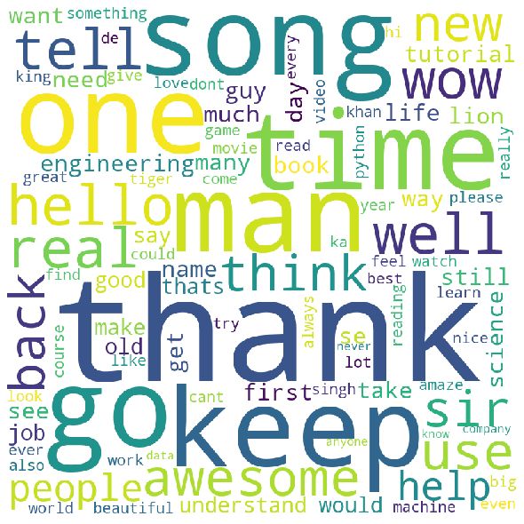

```python
#Generating a word cloud

wordcloud = WordCloud(width = 800, height = 800,
                background_color ='white',
                stopwords = stopwords,
                min_font_size = 10).generate(train_word_list)

# plot the WordCloud image
plt.figure(figsize = (8, 8), facecolor = None)
plt.imshow(wordcloud)
plt.axis("off")
plt.tight_layout(pad = 0)

plt.show()
```

#### By looking at the above word cloud, we can see that words positive words like thank, beautiful, amaze constitute a large portion of our dataset. Also words related to education and job search such as course, jobs, books, tutorial etc. constitute a big part of our data.

### Preparing the labelled hatespeech dataset to train our model

We are using the labeled hatespeech dataset used in the research paper - *Automated Hate Speech Detection and the Problem of Offensive Language* to train our hate speech classifier model.

Paper Reference: https://arxiv.org/pdf/1703.04009.pdf  
Dataset Reference: https://github.com/t-davidson/hate-speech-and-offensive-language

The dataset contains ~25,000 tweets containing strong hate speech lexicons. CrowdFlower (CF) workers have manually labelled these tweets. The CF workers have label each tweet as one of three categories: hate speech, offensive but not hate speech, or neither offensive nor hate speech.

The dataset contains the following columns:

- count = number of CrowdFlower users who coded each tweet (min is 3, sometimes more users coded a tweet when judgments were determined to be unreliable by CF).
- hate_speech = number of CF users who judged the tweet to be hate speech.
- offensive_language = number of CF users who judged the tweet to be offensive.
- neither = number of CF users who judged the tweet to be neither offensive nor non-offensive.
- class = class label for majority of CF users. 0 - hate speech 1 - offensive language 2 - neither
- tweet = Original tweet

```python
# Repeating the same cleaning exercises on the labelled hate speech data

hate_df=pd.read_csv("hatespeech_df.csv")

# Removing the stopwords
hate_df["Clean_Text"]= hate_df.apply(lambda row: stopWordRemoval(row['clean_tweet']), axis=1)

#Lemmatizing the text
hate_df["Lemma_Clean_Text"] = hate_df["Clean_Text"].apply(lambda x:' '.join(lemmatizer.lemmatize(word, pos_tag(word)) for word in x.split()))

hate_df.head()
```

|  | Unnamed: 0 | count | hate_speech | offensive_language | neither | class | tweet | clean_tweet | Clean_Text | Lemma_Clean_Text |
| --- | --- | --- | --- | --- | --- | --- | --- | --- | --- | --- |
| 0 | 0 | 3 | 0 | 0 | 3 | 2 | !!! RT @mayasolovely: As a woman you shouldn't... | mayasolovely as a woman you shouldnt complain... | mayasolovely woman shouldnt complain cleaning ... | mayasolovely woman shouldnt complain cleaning ... |
| 1 | 1 | 3 | 0 | 3 | 0 | 1 | !!!!! RT @mleew17: boy dats cold...tyga dwn ba... | boy dats coldtyga dwn bad for cuffin dat hoe... | boy dats coldtyga dwn bad cuffin dat hoe place | boy dat coldtyga dwn bad cuffin dat hoe place |
| 2 | 2 | 3 | 0 | 3 | 0 | 1 | !!!!!!! RT @UrKindOfBrand Dawg!!!! RT @80sbaby... | urkindofbrand dawg you ever fuck a bitch and... | urkindofbrand dawg ever fuck bitch stato cry c... | urkindofbrand dawg ever fuck bitch stato cry c... |
| 3 | 3 | 3 | 0 | 2 | 1 | 1 | !!!!!!!!! RT @C_G_Anderson: @viva_based she lo... | cganderson vivabased she look like a tranny | cganderson vivabased look like tranny | cganderson vivabased look like tranny |
| 4 | 4 | 6 | 0 | 6 | 0 | 1 | !!!!!!!!!!!!! RT @ShenikaRoberts: The shit you... | shenikaroberts the shit you hear about me mig... | shenikaroberts shit hear might true might fake... | shenikaroberts shit hear might true might fake... |

```python
hateful_df = hate_df.drop(['count', 'offensive_language','neither','hate_speech','Unnamed: 0'], axis=1)
```

The below hate speech training dataset has been cleaned in the same way as our original dataset.

```python
hateful_df.head()
```

|  | class | tweet | clean_tweet | Clean_Text | Lemma_Clean_Text |
| --- | --- | --- | --- | --- | --- |
| 0 | 2 | !!! RT @mayasolovely: As a woman you shouldn't... | mayasolovely as a woman you shouldnt complain... | mayasolovely woman shouldnt complain cleaning ... | mayasolovely woman shouldnt complain cleaning ... |
| 1 | 1 | !!!!! RT @mleew17: boy dats cold...tyga dwn ba... | boy dats coldtyga dwn bad for cuffin dat hoe... | boy dats coldtyga dwn bad cuffin dat hoe place | boy dat coldtyga dwn bad cuffin dat hoe place |
| 2 | 1 | !!!!!!! RT @UrKindOfBrand Dawg!!!! RT @80sbaby... | urkindofbrand dawg you ever fuck a bitch and... | urkindofbrand dawg ever fuck bitch stato cry c... | urkindofbrand dawg ever fuck bitch stato cry c... |
| 3 | 1 | !!!!!!!!! RT @C_G_Anderson: @viva_based she lo... | cganderson vivabased she look like a tranny | cganderson vivabased look like tranny | cganderson vivabased look like tranny |
| 4 | 1 | !!!!!!!!!!!!! RT @ShenikaRoberts: The shit you... | shenikaroberts the shit you hear about me mig... | shenikaroberts shit hear might true might fake... | shenikaroberts shit hear might true might fake... |

```python
#Calculating the count of each class in the dataset

hateful_df["class"].value_counts()
```

```
1    19190
2     4163
0     1430
Name: class, dtype: int64
```

```python
hateful_df.to_csv("lemma_hateful_df.csv")
```

#### Since our training data is class imbalanced, we are selecting equal number of rows in each class to train our dataset on.

```python
size = 1430        # sample size
replace = False  # without replacement
fn = lambda obj: obj.loc[np.random.choice(obj.index, size, replace),:]
hateful_df=hateful_df.groupby('class', as_index=False).apply(fn)
```

```python
#Training dataset is class balanced

hateful_df["class"].value_counts()
```

```
2    1430
1    1430
0    1430
Name: class, dtype: int64
```

#### We are using a TF-IDF vectorizer to tokenize our data

```python
#Tokenizing the data

vectorizer = TfidfVectorizer()
vect = vectorizer.fit_transform(hateful_df["Lemma_Clean_Text"].values)
words = vectorizer.get_feature_names()
```

```python
hate_model_df = pd.DataFrame.sparse.from_spmatrix(vect)
hate_model_df.columns = words
hate_model_df
```

|  | aa | aaaaaaaaand | aamaadmiparty | aampt | aap | aaron | aaronmacgruder | aasthaxoxo | ab | abbey | ... | zohdaa | zone | zonedmoan | zoo | zooyorkinit | zorro | ztsupreme | zwaaad | zzachbarness | zzzzzz |
| --- | --- | --- | --- | --- | --- | --- | --- | --- | --- | --- | --- | --- | --- | --- | --- | --- | --- | --- | --- | --- | --- |
| 0 | 0.0 | 0.0 | 0.0 | 0.0 | 0.0 | 0.0 | 0.0 | 0.0 | 0.0 | 0.0 | ... | 0.0 | 0.0 | 0.0 | 0.0 | 0.0 | 0.0 | 0.0 | 0.0 | 0.0 | 0.0 |
| 1 | 0.0 | 0.0 | 0.0 | 0.0 | 0.0 | 0.0 | 0.0 | 0.0 | 0.0 | 0.0 | ... | 0.0 | 0.0 | 0.0 | 0.0 | 0.0 | 0.0 | 0.0 | 0.0 | 0.0 | 0.0 |
| 2 | 0.0 | 0.0 | 0.0 | 0.0 | 0.0 | 0.0 | 0.0 | 0.0 | 0.0 | 0.0 | ... | 0.0 | 0.0 | 0.0 | 0.0 | 0.0 | 0.0 | 0.0 | 0.0 | 0.0 | 0.0 |
| 3 | 0.0 | 0.0 | 0.0 | 0.0 | 0.0 | 0.0 | 0.0 | 0.0 | 0.0 | 0.0 | ... | 0.0 | 0.0 | 0.0 | 0.0 | 0.0 | 0.0 | 0.0 | 0.0 | 0.0 | 0.0 |
| 4 | 0.0 | 0.0 | 0.0 | 0.0 | 0.0 | 0.0 | 0.0 | 0.0 | 0.0 | 0.0 | ... | 0.0 | 0.0 | 0.0 | 0.0 | 0.0 | 0.0 | 0.0 | 0.0 | 0.0 | 0.0 |
| ... | ... | ... | ... | ... | ... | ... | ... | ... | ... | ... | ... | ... | ... | ... | ... | ... | ... | ... | ... | ... | ... |
| 4285 | 0.0 | 0.0 | 0.0 | 0.0 | 0.0 | 0.0 | 0.0 | 0.0 | 0.0 | 0.0 | ... | 0.0 | 0.0 | 0.0 | 0.0 | 0.0 | 0.0 | 0.0 | 0.0 | 0.0 | 0.0 |
| 4286 | 0.0 | 0.0 | 0.0 | 0.0 | 0.0 | 0.0 | 0.0 | 0.0 | 0.0 | 0.0 | ... | 0.0 | 0.0 | 0.0 | 0.0 | 0.0 | 0.0 | 0.0 | 0.0 | 0.0 | 0.0 |
| 4287 | 0.0 | 0.0 | 0.0 | 0.0 | 0.0 | 0.0 | 0.0 | 0.0 | 0.0 | 0.0 | ... | 0.0 | 0.0 | 0.0 | 0.0 | 0.0 | 0.0 | 0.0 | 0.0 | 0.0 | 0.0 |
| 4288 | 0.0 | 0.0 | 0.0 | 0.0 | 0.0 | 0.0 | 0.0 | 0.0 | 0.0 | 0.0 | ... | 0.0 | 0.0 | 0.0 | 0.0 | 0.0 | 0.0 | 0.0 | 0.0 | 0.0 | 0.0 |
| 4289 | 0.0 | 0.0 | 0.0 | 0.0 | 0.0 | 0.0 | 0.0 | 0.0 | 0.0 | 0.0 | ... | 0.0 | 0.0 | 0.0 | 0.0 | 0.0 | 0.0 | 0.0 | 0.0 | 0.0 | 0.0 |

4290 rows × 9261 columns

### Step 2: Training our hate speech detection model

For this exercise, we are testing the below 3 classifiers to accurately classify our data into hate or offensive speech or neither:

1) Logistic Regression Classifier

2) LightGBM Classifier

3) Naive Bayes Classifier

#### Splitting the dataset into training and validation sets having a 80-20 split to check model accuracy

```python
y = pd.DataFrame(hateful_df['class'])
x_train,x_valid,y_train,y_valid = train_test_split(hate_model_df,y,test_size = 0.2,random_state = 1)
```

#### Logistic Regrssion Model

```python
log_reg_mod = LogisticRegression(penalty = 'l2', multi_class="auto", random_state = 1).fit(x_train, y_train.values.ravel())
log_reg_yhat = log_reg_mod.predict(x_valid)

labels = np.unique(y_valid)
prediction_lr =confusion_matrix(y_valid, log_reg_yhat, labels=labels)
class_report_lr = classification_report(y_valid, log_reg_yhat, output_dict=True)
prediction_lr_df = pd.DataFrame(prediction_lr, index=labels, columns=labels)

print('\nThe Accuracy Score for Regularized Logistic Regression Model:', round((accuracy_score(y_valid, log_reg_yhat))*100,2),"%")
```

```
The Accuracy Score for Regularized Logistic Regression Model: 80.19 %
```

```python
print("\nClassification Report for Regularized Logistic Regression Model: \n")
pd.DataFrame(class_report_lr).transpose()
```

```
Classification Report for Regularized Logistic Regression Model:
```

|  | precision | recall | f1-score | support |
| --- | --- | --- | --- | --- |
| 0 | 0.820513 | 0.668990 | 0.737044 | 287.000000 |
| 1 | 0.782759 | 0.793706 | 0.788194 | 286.000000 |
| 2 | 0.805389 | 0.943860 | 0.869144 | 285.000000 |
| accuracy | 0.801865 | 0.801865 | 0.801865 | 0.801865 |
| macro avg | 0.802887 | 0.802185 | 0.798127 | 858.000000 |
| weighted avg | 0.802905 | 0.801865 | 0.797973 | 858.000000 |

```python
#Confusion Mtrix
print("\nConfusion Matrix for Regularized Logistic Regression Model: \n")

prediction_lr_df
```

```
Confusion Matrix for Regularized Logistic Regression Model:
```

|  | 0 | 1 | 2 |
| --- | --- | --- | --- |
| 0 | 192 | 58 | 37 |
| 1 | 31 | 227 | 28 |
| 2 | 11 | 5 | 269 |

#### Light GBM model

```python
#Using LightGBM model
lgb_clf = lgb.LGBMClassifier(boosting_type='gbdt',
                                  objective='multiclass',
                                  num_class= 3,
                                  random_state = 1,
                                  ).fit(x_train,y_train.values.ravel())
lgb_yhat = lgb_clf.predict(x_valid)
prediction_lgb=  confusion_matrix(y_valid, lgb_yhat, labels=labels)
prediction_lgb_df = pd.DataFrame(prediction_lgb, index=labels, columns=labels)

class_report_lgb = classification_report(y_valid, lgb_yhat, output_dict=True)
print('The Accuracy Score for Gradient Boosting: ', round(accuracy_score(y_valid, lgb_yhat)*100,2),"%")
```

```
The Accuracy Score for Gradient Boosting:  78.32 %
```

```python
print("\nClassification Report for Gradient Boosting: \n")
pd.DataFrame(class_report_lgb).transpose()
```

```
Classification Report for Gradient Boosting:
```

|  | precision | recall | f1-score | support |
| --- | --- | --- | --- | --- |
| 0 | 0.756000 | 0.658537 | 0.703911 | 287.000000 |
| 1 | 0.782918 | 0.769231 | 0.776014 | 286.000000 |
| 2 | 0.804281 | 0.922807 | 0.859477 | 285.000000 |
| accuracy | 0.783217 | 0.783217 | 0.783217 | 0.783217 |
| macro avg | 0.781066 | 0.783525 | 0.779801 | 858.000000 |
| weighted avg | 0.781010 | 0.783217 | 0.779619 | 858.000000 |

```python
#Confusion Matrix

print("Confusion Matrix for Gradient Boosting:\n")
prediction_lgb_df
```

```
Confusion Matrix for Gradient Boosting:
```

|  | 0 | 1 | 2 |
| --- | --- | --- | --- |
| 0 | 189 | 54 | 44 |
| 1 | 46 | 220 | 20 |
| 2 | 15 | 7 | 263 |

#### Naive Bayes Classifier

```python
#Using Naive Bayes Model
random.seed(1)
nb_clf = MultinomialNB(alpha=0.1)
nb_model=nb_clf.fit(x_train, y_train.values.ravel())
nb_yhat = nb_model.predict(x_valid)
prediction_nb=  confusion_matrix(y_valid, nb_yhat, labels=labels)
prediction_nb_df = pd.DataFrame(prediction_nb, index=labels, columns=labels)

class_report_nb = classification_report(y_valid, nb_yhat, output_dict=True)
nb_acc=accuracy_score(y_valid, nb_yhat)
print("The Accuracy of Naive Bayes Model:",round(nb_acc*100,2),"%")
accuracy = {}
accuracy[0] = round(nb_acc*100,2)
```

```
The Accuracy of Naive Bayes Model: 69.7 %
```

```python
print("\nClassification Report for Naive Bayes Model: \n")
pd.DataFrame(class_report_nb).transpose()
```

```
Classification Report for Naive Bayes Model:
```

|  | precision | recall | f1-score | support |
| --- | --- | --- | --- | --- |
| 0 | 0.641379 | 0.648084 | 0.644714 | 287.00000 |
| 1 | 0.639144 | 0.730769 | 0.681892 | 286.00000 |
| 2 | 0.842324 | 0.712281 | 0.771863 | 285.00000 |
| accuracy | 0.696970 | 0.696970 | 0.696970 | 0.69697 |
| macro avg | 0.707616 | 0.697045 | 0.699490 | 858.00000 |
| weighted avg | 0.707381 | 0.696970 | 0.699342 | 858.00000 |

```python
#Confusion Matrix

print("Confusion Matrix for Naive Bayes Model:\n")
prediction_nb_df
```

```
Confusion Matrix for Naive Bayes Model:
```

|  | 0 | 1 | 2 |
| --- | --- | --- | --- |
| 0 | 186 | 79 | 22 |
| 1 | 61 | 209 | 16 |
| 2 | 43 | 39 | 203 |

#### Comparing the classifiers

```python
print('The accuracy of the Regularized Logistic Regression classifier is', round((accuracy_score(y_valid, log_reg_yhat))*100,2),"%")
print('\nThe accuracy of the Light GBM classifier is ', round(accuracy_score(y_valid, lgb_yhat)*100,2),"%")
print("\nThe accuracy of the Naive Bayes classifier is",round(nb_acc*100,2),"%")
```

```
The accuracy of the Regularized Logistic Regression classifier is 80.19 %

The accuracy of the Light GBM classifier is  78.32 %

The accuracy of the Naive Bayes classifier is 69.7 %
```

```python
#Classwise accuracy calculation

nb_mod_accuracy = []
total_count = (prediction_nb_df).sum(axis = 1)
correct_class = []
for index, row in prediction_nb_df.iterrows():
    correct_class.append(row[index])
nb_mod_accuracy = round((correct_class / total_count),2)*100
```

```python
tree_mod_accuracy = []
total_count = (prediction_lgb_df).sum(axis = 1)
correct_class = []
for index, row in prediction_lgb_df.iterrows():
    correct_class.append(row[index])
tree_mod_accuracy = round((correct_class / total_count),2)*100
```

```python
log_reg_accuracy = []
total_count = (prediction_lr_df).sum(axis = 1)
correct_class = []
for index, row in prediction_lr_df.iterrows():
    correct_class.append(row[index])
log_reg_accuracy = round((correct_class / total_count),2)*100
```

#### Plotting the classwise accuracy for each classifier

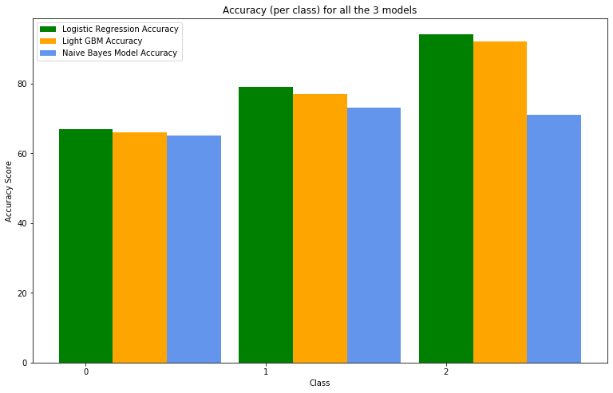

```python
#Plotting the Accuracy for each class for all the three models
X = np.arange(3)
fig=plt.gcf()
fig.set_size_inches(10,6)
ax = fig.add_axes([0,0,1,1])
ax.bar(X + 0.00, log_reg_accuracy, color = 'g', width = 0.30, label ='Logistic Regression Accuracy')
ax.bar(X + 0.30, tree_mod_accuracy, color = 'orange', width = 0.30,label ='Light GBM Accuracy')
ax.bar(X + 0.60, nb_mod_accuracy, color = 'cornflowerblue', width = 0.30, label ='Naive Bayes Model Accuracy')
plt.title("Accuracy (per class) for all the 3 models")
plt.xlabel("Class")
plt.ylabel("Accuracy Score")
plt.xticks(X,prediction_lr_df.index)
plt.legend()
```

Thus, by analyzing the results from all the 3 models, we have decided to use the Logistic Regression model to detect hate speech in our dataset as it gave the best results among all the 3 models.

### Step 3: Prediction of hate speech on our extracted data

#### Preparing our extracted data to be used by the model for prediction

```python
#Tokenizing the data
vect = vectorizer.transform(df["Lemma_Clean_Text"].values)
words = vectorizer.get_feature_names()
model_df = pd.DataFrame.sparse.from_spmatrix(vect)
model_df.columns = words
model_df
```

|  | aa | aaaaaaaaand | aamaadmiparty | aampt | aap | aaron | aaronmacgruder | aasthaxoxo | ab | abbey | ... | zohdaa | zone | zonedmoan | zoo | zooyorkinit | zorro | ztsupreme | zwaaad | zzachbarness | zzzzzz |
| --- | --- | --- | --- | --- | --- | --- | --- | --- | --- | --- | --- | --- | --- | --- | --- | --- | --- | --- | --- | --- | --- |
| 0 | 0.0 | 0.0 | 0.0 | 0.0 | 0.0 | 0.0 | 0.0 | 0.0 | 0.0 | 0.0 | ... | 0.0 | 0.0 | 0.0 | 0.0 | 0.0 | 0.0 | 0.0 | 0.0 | 0.0 | 0.0 |
| 1 | 0.0 | 0.0 | 0.0 | 0.0 | 0.0 | 0.0 | 0.0 | 0.0 | 0.0 | 0.0 | ... | 0.0 | 0.0 | 0.0 | 0.0 | 0.0 | 0.0 | 0.0 | 0.0 | 0.0 | 0.0 |
| 2 | 0.0 | 0.0 | 0.0 | 0.0 | 0.0 | 0.0 | 0.0 | 0.0 | 0.0 | 0.0 | ... | 0.0 | 0.0 | 0.0 | 0.0 | 0.0 | 0.0 | 0.0 | 0.0 | 0.0 | 0.0 |
| 3 | 0.0 | 0.0 | 0.0 | 0.0 | 0.0 | 0.0 | 0.0 | 0.0 | 0.0 | 0.0 | ... | 0.0 | 0.0 | 0.0 | 0.0 | 0.0 | 0.0 | 0.0 | 0.0 | 0.0 | 0.0 |
| 4 | 0.0 | 0.0 | 0.0 | 0.0 | 0.0 | 0.0 | 0.0 | 0.0 | 0.0 | 0.0 | ... | 0.0 | 0.0 | 0.0 | 0.0 | 0.0 | 0.0 | 0.0 | 0.0 | 0.0 | 0.0 |
| ... | ... | ... | ... | ... | ... | ... | ... | ... | ... | ... | ... | ... | ... | ... | ... | ... | ... | ... | ... | ... | ... |
| 6156 | 0.0 | 0.0 | 0.0 | 0.0 | 0.0 | 0.0 | 0.0 | 0.0 | 0.0 | 0.0 | ... | 0.0 | 0.0 | 0.0 | 0.0 | 0.0 | 0.0 | 0.0 | 0.0 | 0.0 | 0.0 |
| 6157 | 0.0 | 0.0 | 0.0 | 0.0 | 0.0 | 0.0 | 0.0 | 0.0 | 0.0 | 0.0 | ... | 0.0 | 0.0 | 0.0 | 0.0 | 0.0 | 0.0 | 0.0 | 0.0 | 0.0 | 0.0 |
| 6158 | 0.0 | 0.0 | 0.0 | 0.0 | 0.0 | 0.0 | 0.0 | 0.0 | 0.0 | 0.0 | ... | 0.0 | 0.0 | 0.0 | 0.0 | 0.0 | 0.0 | 0.0 | 0.0 | 0.0 | 0.0 |
| 6159 | 0.0 | 0.0 | 0.0 | 0.0 | 0.0 | 0.0 | 0.0 | 0.0 | 0.0 | 0.0 | ... | 0.0 | 0.0 | 0.0 | 0.0 | 0.0 | 0.0 | 0.0 | 0.0 | 0.0 | 0.0 |
| 6160 | 0.0 | 0.0 | 0.0 | 0.0 | 0.0 | 0.0 | 0.0 | 0.0 | 0.0 | 0.0 | ... | 0.0 | 0.0 | 0.0 | 0.0 | 0.0 | 0.0 | 0.0 | 0.0 | 0.0 | 0.0 |

6161 rows × 9261 columns

#### Using the logistic regression model to detect hate speech

```python
labels_yhat = list(log_reg_mod.predict(model_df))
```

```python
labels_yhat_df=pd.DataFrame(labels_yhat, columns=["Class"])
```

#### Appending the predicted labels to our dataset

```python
predicted_df=df.join(labels_yhat_df)
predicted_df=predicted_df[["Text","Date", "Source","Class"]]
```

```python
predicted_df
```

[output not shown]

6161 rows × 4 columns

#### After predicting the labels from our model, we can see that only 3% of our dataset contains hate speech or offensive speech

```python
predicted_df.Class.value_counts()
```

```
2    5941
1     159
0      61
Name: Class, dtype: int64
```

```python
predicted_df.to_csv("predicted_df.csv", index=False)
```

### Step 4: Using sentiment analysis to tag additional hate speech not identified by the model

In this step, we will be using VADER sentiment analysis, Opinion Lexicon for swear words and perform a manual review to identify hate speech that was not detected by our model. We will be using the below steps to perform this exercise.

a) Use VADER sentiment analysis to identify negative sentiment speech in our dataset

b) Use the opinion lexicon swear words dictionary to identify offensive/hate speech on the negative text identified by VADER

c) Perform a manual review on the hate speech tagged data to further validate the accuracy

d) Combine the results from our hate speech detection model and sentiment analysis and create a final dataset with accurately labelled data

#### (a) Vader analysis to identify negative sentiment

VADER (Valence Aware Dictionary and sEntiment Reasoner) is a lexicon and rule-based sentiment analysis tool that is specifically attuned to sentiments expressed in social media, and works well on texts from other domains. This tool takes raw text as input and provides a range of sentiment scores (positive, neutral, negative, compound) for the sentence. This tool takes into account the capitalization of letters, emojis and punctuations used in the sentence to generate a sentiment score and works very well for analyzing the sentiment of Twitter data.

Scoring scale:

The compound score is computed by summing the valence scores of each word in the lexicon, adjusted according to the rules, and then normalized to be between -1 (most extreme negative) and +1 (most extreme positive).The suggested threshold values are:

a) Positive sentiment: compound score >= 0.05

b) Neutral sentiment: (compound score > -0.05) and (compound score < 0.05)

c) Negative sentiment: compound score <= -0.05

```python
from vaderSentiment.vaderSentiment import SentimentIntensityAnalyzer
```

```python
data = pd.read_csv('predicted_df.csv')
data['Text'] = data['Text'].astype('str')
```

```python
vaderSentimentAnalyzer = SentimentIntensityAnalyzer()
data['vaderSentimentScores'] = [vaderSentimentAnalyzer.polarity_scores(text)['compound'] for text in data['Text']]
data['vaderSentiment'] = np.where(data['vaderSentimentScores'] >= 0.05,"positive",
                                np.where(data['vaderSentimentScores'] <= -0.05,"negative",
                                         "neutral"))
data.head()
```

|  | Text | Date | Source | Class | vaderSentimentScores | vaderSentiment |
| --- | --- | --- | --- | --- | --- | --- |
| 0 | chef de partie alton tronc tips benefits job... | 1/1/2020 | twitter | 2 | 0.3818 | positive |
| 1 | deputy manager sevenoaks tips bonus live ... | 1/1/2020 | twitter | 2 | 0.7269 | positive |
| 2 | wildcatvc joboftheweek reach is looking for a ... | 1/1/2020 | twitter | 2 | 0.0258 | neutral |
| 3 | roving sous chef kent tips bonus mileage b... | 1/1/2020 | twitter | 2 | 0.7269 | positive |
| 4 | group manager london benefits job jobs hi... | 1/1/2020 | twitter | 2 | 0.3818 | positive |

#### Gathering texts with only negative vader sentiment to set a negative connotation for our hateful speech words.

```python
dataCopy = data[data['vaderSentiment'] == 'negative'].copy().reset_index(drop=True)
```

#### (b) Use the opinion lexicon swear words dictionary to identify offensive/hate speech on the negative text identified by VADER

```python
LIWCDataFrame = pd.read_excel("LIWC_Dictionary.xlsx")
```

```python
def wordsWithAsterix(allWords):
    asterixWords = []
    for word in allWords:
        if word[-1] == '*':
            asterixWords.append(word)
    return asterixWords
```

```python
# FROM LIWC, FINDING SWEAR RELATED WORDS WHICH COMPRISE MOST OF OUR HATEFUL SPEECH WORDS, Swear and Anger words mostly.
swearDataFrame = LIWCDataFrame.loc[:,['Swear']]
swearDataFrame
```

|  | Swear |
| --- | --- |
| 0 | af |
| 1 | arse |
| 2 | arsehole* |
| 3 | arses |
| 4 | asf |
| ... | ... |
| 225 | NaN |
| 226 | NaN |
| 227 | NaN |
| 228 | NaN |
| 229 | NaN |

230 rows × 1 columns

```python
hateWords = list(set(pd.unique(swearDataFrame[['Swear']].values.ravel('K'))))
hateWords.remove(np.nan)
```

```python
# finding words with asterix
asterixHateWords = wordsWithAsterix(hateWords)

# finding words without asterix
hateWordsWithoutAsterix = list(set(hateWords) - set(asterixHateWords))

print('Total swear related words: ', len(hateWords))
print('Total swear related words without asterix: ', len(hateWordsWithoutAsterix))
print('Total swear related words with asterix: ', len(asterixHateWords))
```

```
Total swear related words:  131
Total swear related words without asterix:  71
Total swear related words with asterix:  60
```

#### If we find the text contains swear words, we will classify it as '0' ~ hate; taking into consideration our nomenclature in the previous parts; otherwise we will classifiy it into category '2' ~ neither.

```python
for i in range(len(dataCopy)):
    Class = int(2)
    for word in (data.iloc[i, 0]).split(' '):
        '''
        to check whether word is in lists of words without asterix or
        whether word is A PART OF list of words WITH ASTERIX (Using REGEX)
        '''
        if word in hateWordsWithoutAsterix or re.match('(?:% s)' % '|'.join(asterixHateWords), word):
            Class = int(0)
            pass

    dataCopy.loc[i, 'Vader_Class'] = Class
```

```python
dataCopy
```

|  | Text | Date | Source | Class | vaderSentimentScores | vaderSentiment | Vader_Class |
| --- | --- | --- | --- | --- | --- | --- | --- |
| 0 | now hiring emergency veterinarian austin area ... | 1/1/2020 | twitter | 2 | -0.1779 | negative | 2.0 |
| 1 | risk strategist loss prevention san francisco ... | 1/1/2020 | twitter | 2 | -0.5267 | negative | 2.0 |
| 2 | auramvasquez my goals for get elected to the ... | 1/1/2020 | twitter | 2 | -0.3818 | negative | 2.0 |
| 3 | nlrb concludes recusal procedure strong but po... | 1/1/2020 | twitter | 2 | -0.2382 | negative | 0.0 |
| 4 | how social media can sabotage your executive j... | 1/1/2020 | twitter | 2 | -0.5267 | negative | 2.0 |
| ... | ... | ... | ... | ... | ... | ... | ... |
| 397 | no education no food black shit poop | 2/21/2021 | youtube | 0 | -0.6010 | negative | 2.0 |
| 398 | bitch covid took my job | 3/9/2021 | twitter | 0 | -0.5859 | negative | 2.0 |
| 399 | no school no work bitchess | 6/10/2020 | reddit | 0 | -0.0803 | negative | 2.0 |
| 400 | stop bullshit about homework | 6/10/2020 | reddit | 0 | -0.7184 | negative | 2.0 |
| 401 | cunt bitch life education fuck asian | 3/9/2021 | twitter | 0 | -0.8885 | negative | 2.0 |

402 rows × 7 columns

```python
dataCopy.Vader_Class = dataCopy.Vader_Class.astype(int)
dataCopy.Vader_Class.value_counts()
```

```
2    387
0     15
Name: Vader_Class, dtype: int64
```

```python
dataCopy.to_csv("vader_data.csv",index=False)
```

### On performing a manual review on the data identified as hate/offensive speech by the VADER model and Opinion Lexicon, we can see that none of the text truly corresponds to hate speech. Hence, we will not be using the results from this approach to add on to the hate speech data labelled by our model.

```python
pd.set_option('display.max_colwidth', 500)
dataCopy.loc[dataCopy["Vader_Class"]==0]
```

|  | Text | Date | Source | Class | vaderSentimentScores | vaderSentiment | Vader_Class |
| --- | --- | --- | --- | --- | --- | --- | --- |
| 3 | nlrb concludes recusal procedure strong but potential for circular firing squad persists att pfizer glaxosmithkline utilities gasutilities utilities gasutilities attjobs jobs layoff | 1/1/2020 | twitter | 2 | -0.2382 | negative | 0 |
| 6 | oben links auf bewerben klicken unten gibt es noch arbeitsstellen job arbeit jobs telefon nummer und adresse der polizei wo dein führungszeugnis liegt an die firma mit der post senden | 1/2/2020 | twitter | 2 | -0.5994 | negative | 0 |
| 37 | most resolutions fail yours dont have to take note of these achievable resolutions that are suitable for every industry and every experience levelcareeradvice newyearresolutions hiring jobs | 1/8/2020 | twitter | 2 | -0.3566 | negative | 0 |
| 45 | what with megxit and all the slack in the us labor market just went upbut seriously tomorrow i will be talking jobs on bloombergtv wadsteel and others from estimates of labor mkt slack have been falli… | 1/9/2020 | twitter | 2 | -0.3182 | negative | 0 |
| 46 | businesscycle growth in total hours worked has slowed to its weakest reading since this is consistent with ecris slowdown… | 1/10/2020 | twitter | 2 | -0.1779 | negative | 0 |
| 56 | erc americas emergency management company ericsson location são paulo sp brazil são paulo political engineering jobs more info at | 1/11/2020 | twitter | 2 | -0.3818 | negative | 0 |
| 149 | my whatsapp no | 12/27/2020 | youtube | 2 | -0.2960 | negative | 0 |
| 184 | hi no | 1/29/2021 | youtube | 2 | -0.2960 | negative | 0 |
| 208 | sarkari naukari walon ko bahan ko chhod dun tumhari mein aansu dun tum kota kota samasya kyon batate hain ointment logon ko kis tarah banate ho tum log complaint kar denge ham tumhari | 1/29/2021 | youtube | 2 | -0.2960 | negative | 0 |
| 224 | very hot 🔥🔥🔥🔥🔥🔥🔥 | 1/29/2021 | youtube | 2 | -0.9365 | negative | 0 |
| 228 | neha ko maa bana dunge my no call karo | 1/29/2021 | youtube | 2 | -0.2960 | negative | 0 |
| 270 | mental block cannot remember name email client could trello style viewslanes drag emails ie todo later etc etcdoes exist making uphelp | 1/6/2020 | reddit | 2 | -0.5859 | negative | 0 |
| 362 | illinois work nurse unit worked nurse closed told us days supposed close unit gave us options sign furlough placed different unit quit opted sign furlough denied quit applied unemployment got weeks un… | 6/10/2020 | reddit | 2 | -0.6249 | negative | 0 |
| 363 | im suppose making week last weeks gotten additional back pay overpayment | 6/10/2020 | reddit | 2 | -0.1027 | negative | 0 |
| 371 | finally able get ahold someone fixed id problem long updated money come need badly | 6/10/2020 | reddit | 2 | -0.7003 | negative | 0 |

## Project Phase 3: Final Analysis

### Insights:

Although we were able to classify only ~3% of our dataset as hate or offensive speech using our model, we were able to analyze the following:

1) Hate speech was more pervasive in the post pandemic period whereas offensive speech was higher in the pre pandemic period

2) Youtube has the highest number of hate speech comments post the pandemic whereas Reddit has the highest number of hate speech in the pre pandemic period

## Data Visualizations

#### Marking data before 03/11/2020 as pre-pandemic in congruence with the declaration made by WHO

```python
predicted_df=pd.read_csv("predicted_df.csv")
predicted_df["Period"]="Before Pandemic"
predicted_df["Period"]=np.where(predicted_df["Date"].astype('datetime64[ns]')>date(2020, 3, 11),"Post Pandemic",predicted_df["Period"])
```

### 1) Comparing the number of hate and offensive speech in the pre and post pandemic period

```python
predicted_df_copy = predicted_df.copy()
predicted_df_copy=predicted_df_copy.loc[(predicted_df_copy["Class"]==0) | (predicted_df_copy["Class"]==1) ]
viz3=predicted_df_copy.groupby(["Period","Class"]).size().reset_index(name='Counts')
```

```python
#Normalizing the counts for comparitive analysis since the data was not balanced among the classes
viz3["Counts_2"]=np.where(viz3["Period"]=="Before Pandemic", (viz3["Counts"]*2.4375)/312, viz3["Counts"]/312)
viz3["Normalized_Counts"]=round(viz3["Counts_2"]*100,0)
```

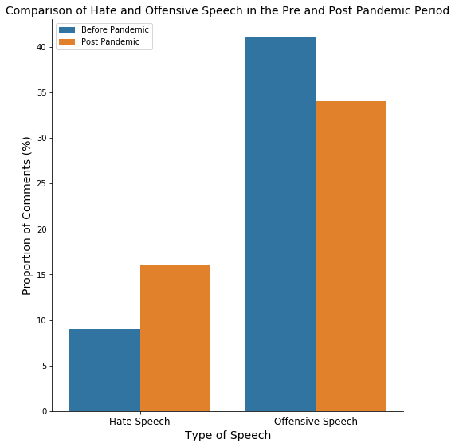

```python
labels=["Hate Speech", "Offensive Speech"]
g=sns.catplot(x = "Class",       # x variable name
            y = "Normalized_Counts",       # y variable name
            hue = "Period",  # group variable name
            data = viz3,     # dataframe to plot
            kind = "bar")
g._legend.remove()
g.fig.set_size_inches(10,8)
plt.ylabel("Proportion of Comments (%)", fontsize=14)
plt.xlabel("Type of Speech", fontsize=14)
plt.title("Comparison of Hate and Offensive Speech in the Pre and Post Pandemic Period", fontsize=14)
g.set_xticklabels(labels, fontsize=12)
plt.legend(loc="upper left", fontsize=10)
```

#### By looking at the above chart, we can see that the amount of hate speech in the post pandemic period as compared to the pre pandemic period. However, the amount of offensive speech is higher in the pre pandemic period as compared to the post pandemic period.

### Comparitive analysis of hate speech proliferation on social media platforms

```python
viz=predicted_df.groupby(["Source","Period","Class"]).size().reset_index(name='Counts')
```

```python
viz1=viz.loc[viz["Class"]==0]
viz1=viz1[["Period","Counts","Source"]]

#Normalizing the counts for comparitive analysis since the data was not balanced among the sources
viz1["Counts_2"]=np.where(viz1["Source"]=="reddit", (viz1["Counts"]*2.143)/90, np.where(viz1["Source"]=="twitter", (viz1["Counts"]*1.765)/90, viz1["Counts"]/90 ))
viz1["Normalized_Counts"]=round(viz1["Counts_2"]*100,0)
```

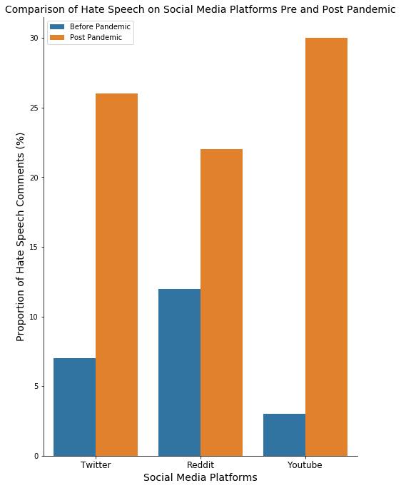

```python
#Comparing the spread of hatespeech on our social media platforms
labels=["Twitter", "Reddit", "Youtube"]
g=sns.catplot(x = "Source",       # x variable name
            y = "Normalized_Counts",       # y variable name
            hue = "Period",  # group variable name
            data = viz1,     # dataframe to plot
            kind = "bar")
g._legend.remove()
g.fig.set_size_inches(10,10)
plt.ylabel("Proportion of Hate Speech Comments (%)", fontsize=14)
plt.xlabel("Social Media Platforms", fontsize=14)
plt.title("Comparison of Hate Speech on Social Media Platforms Pre and Post Pandemic", fontsize=14)
g.set_xticklabels(["Twitter", "Reddit", "Youtube"], fontsize=12)
plt.legend(loc="upper left", fontsize=10)
```

#### By looking at the above chart, we can see that Youtube has the highest number of hate speech comments post the pandemic whereas Reddit has the highest number of hate speech in the pre pandemic period.

```python
viz2=viz.loc[viz["Class"]==1]
viz2=viz2[["Period","Counts","Source"]]

#Normalizing the counts for comparitive analysis since the data was not balanced among the sources
viz2["Counts_2"]=np.where(viz2["Source"]=="reddit", (viz2["Counts"]*2.465)/318, np.where(viz2["Source"]=="twitter", (viz2["Counts"]*10.6)/318, viz2["Counts"]/318))
viz2["Normalized_Counts"]=round(viz2["Counts_2"]*100,0)
```

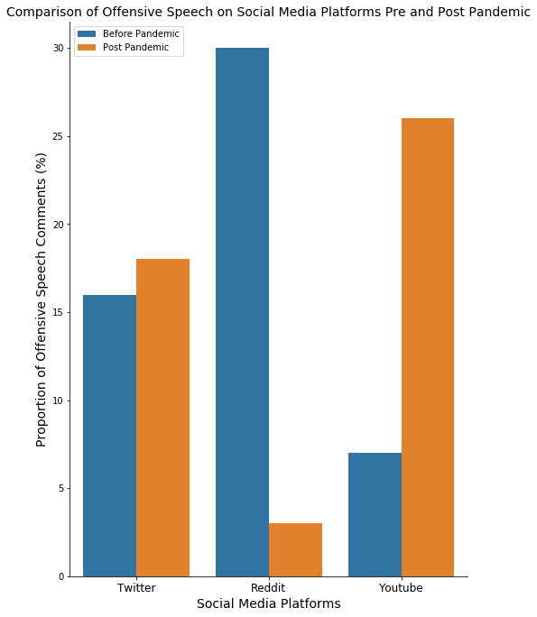

```python
#Comparing the spread of offensive speech on our social media platforms
labels=["Twitter", "Reddit", "Youtube"]
g=sns.catplot(x = "Source",       # x variable name
            y = "Normalized_Counts",       # y variable name
            hue = "Period",  # group variable name
            data = viz2,     # dataframe to plot
            kind = "bar")
g._legend.remove()
g.fig.set_size_inches(10,10)
plt.ylabel("Proportion of Offensive Speech Comments (%)", fontsize=14)
plt.xlabel("Social Media Platforms", fontsize=14)
plt.title("Comparison of Offensive Speech on Social Media Platforms Pre and Post Pandemic", fontsize=14)
g.set_xticklabels(["Twitter", "Reddit", "Youtube"], fontsize=12)
plt.legend(loc="upper left", fontsize=10)
```

#### By looking at the above chart, we can see that Youtube has the highest number of offensive speech comments in the post pandemic period. Also, Reddit has higher amount of offensive speech in the pre pandemic period as compared to the post pandemic period.

### Generating a word cloud to show the popular words present in the detected hate speech

```python
#Counting the tokens in our data
hate_df=predicted_df.loc[predicted_df["Class"]==0]
cvectorizer = CountVectorizer()
wc_vect = cvectorizer.fit_transform(hate_df.Text.values)
wc_words = cvectorizer.get_feature_names()
wc_df = pd.DataFrame.sparse.from_spmatrix(wc_vect)
wc_df.columns = wc_words
```

```python
#Calculating the frequency of the words
frequency_words = pd.DataFrame((wc_df).sum(axis = 0))
frequency_words.columns = ['words']
cols = list(frequency_words.index)

#sorting words based on frequency
frequency_words=frequency_words.sort_values(by='words', ascending=False)
```

```python
# Getting the top 100 most frequent words
words = set(nltk.corpus.words.words())
indexes = frequency_words.head(100).index
final_words = [word for word in words if (word in indexes)]
train_word_list = ''
train_word_list += " ".join(final_words)+" "
```

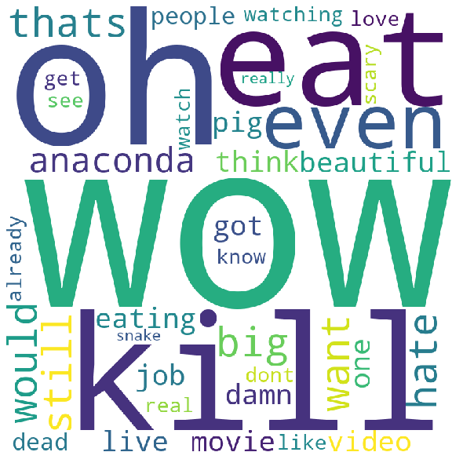

```python
#Generating a word cloud
stopwords = nltk.corpus.stopwords.words('english')

wordcloud = WordCloud(width = 800, height = 800,
                background_color ='white',
                stopwords = stopwords,
                min_font_size = 10).generate(train_word_list)

# plot the WordCloud image
plt.figure(figsize = (8, 8), facecolor = None)
plt.imshow(wordcloud)
plt.axis("off")
plt.tight_layout(pad = 0)

plt.show()
```

## Limitations:

**1) Differentiating between hate speech and offensive speech:**

We realized that there is a fine line between distinguishing hate speech from offensive speech. While words like f#g, b#tch, and n#gger used in both hate speech and offensive language, words such as n#gger, c#nt are more likely used as homophobic slurs and are more associated with hate speech. To more accurately classify such cases we need to find training data that is hateful without containing common keywords associated with offensive language.

**2) Subjectivity in labelled hate speech data:**

Although we have used a manually labelled hate speech dataset to train our model to detect hate speech, the classifications of hate speech tends to reflect our own subjective biases and hence might not result in high levels of accuracy for the hate speech detection model.

**3) API Limitations:**

Due to various API limitions we were unable to extract archived data without premium access to the APIs and also had rate limit restrictions on extracting a large amount of data at one point of time.

**4) Removing bias introduced by events apart from COVID-19 to analyze hate speech proliferation:**

Although we have chosen specific timelines pre and post pandemic to analyze whether COVID-19 has led to the proliferation of hate speech, other personal/local/national events may contribute to the spread of hate speech which may be difficult to rectify while performing our analysis.

## Ethical Considerations:

We do not have any personal or demographical data pertaining to the users whose comments and tweets have been extracted for the purpose of our analysis. Additionally, we have excluded any personal names that were present in our data so that our model is not biased against certain names while flagging hate/offensive speech in our data. Hence, we do not foresee any our project having any ethical concerns.

## Future Work:

**1) Expand our analysis to include more themes:**

For our current project, we have extracted data pertining to the "jobs", "education", "employment" themes pre and post COVID-19 pandemic period. It would be interesting to include additional data pertaining to different themes such as "investing", "healthcare", "travel" etc. and analyze whether there a different pattern in hate speech proliferation for different themes of data.

**2) Analyze whether other events have led to hate speech proliferation apart from COVID-19:**

We can also extend our analysis to understand the proliferation of hate speech before and after other major events over the world such as "Farmers protests in India", "BLM protests" etc. and get interesting insights from the same.

**3) Use complex deep learning and sentiment analysis models:**

We can build robus hate speech detection models by using deep learning algorithms such as BERT, EBPTA etc. to better detect hate speech in our data and contribute to a more accurate analysis.